# Projection Space Exploration – Lifestyle Data

## Goal of the Project

The goal of this project is to explore and analyze a high-dimensional lifestyle dataset using projection techniques. By applying both linear and non-linear dimensionality reduction methods, we aim to uncover meaningful patterns, similarities, and differences between individuals.

In particular, this project focuses on understanding how physiological, nutritional, and activity-related features shape the projection space, and whether these underlying factors explain observed clusters, density variations, and outliers. Rather than merely visualizing point clouds, the analysis emphasizes interpreting projection results in the context of the original data features.

```python
#Imports
import os
import numpy as np
import pandas as pd
import matplotlib.pyplot as plt
```

```python
#Load data
candidate_paths = [
    "Final_data.csv",
    "./Final_data.csv",
    "/mnt/data/Final_data.csv",
]

csv_path = next((p for p in candidate_paths if os.path.exists(p)), None)
if csv_path is None:
    raise FileNotFoundError("Final_data.csv not found. Put it next to the notebook or update the path.")

df = pd.read_csv(csv_path)
df.shape
```

```
(20000, 54)
```

The dataset contains 20,000 samples and 54 features.

```python
#Quick Overview
df.head()
```

|  | Age | Gender | Weight (kg) | Height (m) | Max_BPM | Avg_BPM | Resting_BPM | Session_Duration (hours) | Calories_Burned | Workout_Type | ... | cal_from_macros | pct_carbs | protein_per_kg | pct_HRR | pct_maxHR | cal_balance | lean_mass_kg | expected_burn | Burns Calories (per 30 min)_bc | Burns_Calories_Bin |
| --- | --- | --- | --- | --- | --- | --- | --- | --- | --- | --- | --- | --- | --- | --- | --- | --- | --- | --- | --- | --- | --- |
| 0 | 34.91 | Male | 65.27 | 1.62 | 188.58 | 157.65 | 69.05 | 1.00 | 1080.90 | Strength | ... | 2139.59 | 0.500432 | 1.624789 | 0.741237 | 0.835985 | 725.10 | 47.777394 | 685.1600 | 7.260425e+19 | Medium |
| 1 | 23.37 | Female | 56.41 | 1.55 | 179.43 | 131.75 | 73.18 | 1.37 | 1809.91 | HIIT | ... | 1711.65 | 0.500850 | 1.514093 | 0.551247 | 0.734270 | -232.91 | 40.809803 | 978.6184 | 1.020506e+20 | High |
| 2 | 33.20 | Female | 58.98 | 1.67 | 175.04 | 123.95 | 54.96 | 0.91 | 802.26 | Cardio | ... | 1965.92 | 0.500610 | 1.663445 | 0.574534 | 0.708124 | 805.74 | 44.635580 | 654.5266 | 1.079607e+20 | High |
| 3 | 38.69 | Female | 93.78 | 1.70 | 191.21 | 155.10 | 50.07 | 1.10 | 1450.79 | HIIT | ... | 1627.28 | 0.499533 | 0.862017 | 0.744155 | 0.811150 | 1206.21 | 63.007432 | 773.6300 | 8.987921e+19 | High |
| 4 | 45.09 | Male | 52.42 | 1.88 | 193.58 | 152.88 | 70.84 | 1.08 | 1166.40 | Strength | ... | 2659.23 | 0.500581 | 2.538153 | 0.668405 | 0.789751 | 303.60 | 43.347504 | 711.4176 | 5.264685e+19 | Low |

5 rows × 54 columns

Each row represents an individual with detailed physiological, cardiovascular, activity, and nutritional attributes.

```python
#Quick Overview
df.info()
```

```
<class 'pandas.core.frame.DataFrame'>
RangeIndex: 20000 entries, 0 to 19999
Data columns (total 54 columns):
 #   Column                          Non-Null Count  Dtype
---  ------                          --------------  -----
 0   Age                             20000 non-null  float64
 1   Gender                          20000 non-null  object
 2   Weight (kg)                     20000 non-null  float64
 3   Height (m)                      20000 non-null  float64
 4   Max_BPM                         20000 non-null  float64
 5   Avg_BPM                         20000 non-null  float64
 6   Resting_BPM                     20000 non-null  float64
 7   Session_Duration (hours)        20000 non-null  float64
 8   Calories_Burned                 20000 non-null  float64
 9   Workout_Type                    20000 non-null  object
```

[output cut: 46 more lines]

The dataset contains 20,000 samples described by 54 features, with no missing values. Most features are numerical and represent physiological, cardiovascular, activity, and nutritional aspects, making the dataset well-suited for projection-based analysis.

```python
#Quick Overview
df.describe(include="all").T.head(30)
```

|  | count | unique | top | freq | mean | std | min | 25% | 50% | 75% | max |
| --- | --- | --- | --- | --- | --- | --- | --- | --- | --- | --- | --- |
| Age | 20000.0 | NaN | NaN | NaN | 38.851453 | 12.11458 | 18.0 | 28.17 | 39.865 | 49.63 | 59.67 |
| Gender | 20000 | 2 | Female | 10028 | NaN | NaN | NaN | NaN | NaN | NaN | NaN |
| Weight (kg) | 20000.0 | NaN | NaN | NaN | 73.898832 | 21.17301 | 39.18 | 58.16 | 70.0 | 86.1 | 130.77 |
| Height (m) | 20000.0 | NaN | NaN | NaN | 1.723093 | 0.127033 | 1.49 | 1.62 | 1.71 | 1.8 | 2.01 |
| Max_BPM | 20000.0 | NaN | NaN | NaN | 179.889702 | 11.510805 | 159.31 | 170.0575 | 180.14 | 189.425 | 199.64 |
| Avg_BPM | 20000.0 | NaN | NaN | NaN | 143.704306 | 14.267688 | 119.07 | 131.22 | 142.99 | 156.06 | 169.84 |
| Resting_BPM | 20000.0 | NaN | NaN | NaN | 62.195813 | 7.289351 | 49.49 | 55.96 | 62.2 | 68.09 | 74.5 |
| Session_Duration (hours) | 20000.0 | NaN | NaN | NaN | 1.259446 | 0.341336 | 0.49 | 1.05 | 1.27 | 1.46 | 2.02 |
| Calories_Burned | 20000.0 | NaN | NaN | NaN | 1280.1096 | 502.228982 | 323.11 | 910.8 | 1231.45 | 1553.1125 | 2890.82 |
| Workout_Type | 20000 | 4 | Strength | 5071 | NaN | NaN | NaN | NaN | NaN | NaN | NaN |
| Fat_Percentage | 20000.0 | NaN | NaN | NaN | 26.101313 | 4.99616 | 11.333134 | 22.387807 | 25.822504 | 29.676026 | 35.0 |
| Water_Intake (liters) | 20000.0 | NaN | NaN | NaN | 2.627485 | 0.604724 | 1.46 | 2.17 | 2.61 | 3.12 | 3.73 |
| Workout_Frequency (days/week) | 20000.0 | NaN | NaN | NaN | 3.318629 | 0.911198 | 1.94 | 2.98 | 3.01 | 4.0 | 5.06 |
| Experience_Level | 20000.0 | NaN | NaN | NaN | 1.809176 | 0.736204 | 1.0 | 1.01 | 1.99 | 2.02 | 3.05 |
| BMI | 20000.0 | NaN | NaN | NaN | 24.92168 | 6.701126 | 12.04 | 20.0975 | 24.12 | 28.56 | 50.23 |
| Daily meals frequency | 20000.0 | NaN | NaN | NaN | 2.864804 | 0.636649 | 1.95 | 2.02 | 3.0 | 3.01 | 4.04 |
| Physical exercise | 20000.0 | NaN | NaN | NaN | 0.452503 | 0.986628 | -0.07 | -0.01 | 0.01 | 0.04 | 4.05 |
| Carbs | 20000.0 | NaN | NaN | NaN | 249.778592 | 55.108623 | 137.72 | 207.5475 | 242.9 | 283.975 | 462.49 |
| Proteins | 20000.0 | NaN | NaN | NaN | 99.91829 | 22.04367 | 55.17 | 83.04 | 97.145 | 113.64 | 185.34 |
| Fats | 20000.0 | NaN | NaN | NaN | 66.612172 | 14.699284 | 36.59 | 55.34 | 64.77 | 75.7525 | 123.42 |
| Calories | 20000.0 | NaN | NaN | NaN | 2024.4183 | 541.891521 | 781.0 | 1634.0 | 1919.0 | 2360.0 | 3641.0 |
| meal_name | 20000 | 1 | Other | 20000 | NaN | NaN | NaN | NaN | NaN | NaN | NaN |
| meal_type | 20000 | 4 | Lunch | 5047 | NaN | NaN | NaN | NaN | NaN | NaN | NaN |
| diet_type | 20000 | 6 | Paleo | 3403 | NaN | NaN | NaN | NaN | NaN | NaN | NaN |
| sugar_g | 20000.0 | NaN | NaN | NaN | 24.531042 | 14.446105 | -0.67 | 11.99 | 24.06 | 37.49 | 50.51 |
| sodium_mg | 20000.0 | NaN | NaN | NaN | 1258.139709 | 716.618987 | 19.22 | 645.1275 | 1267.65 | 1850.8925 | 2527.27 |
| cholesterol_mg | 20000.0 | NaN | NaN | NaN | 148.465602 | 87.382817 | -3.89 | 71.97 | 149.795 | 221.84 | 303.99 |
| serving_size_g | 20000.0 | NaN | NaN | NaN | 302.719499 | 115.711949 | 95.95 | 207.2175 | 300.015 | 401.86 | 507.52 |
| cooking_method | 20000 | 7 | Baked | 2953 | NaN | NaN | NaN | NaN | NaN | NaN | NaN |
| prep_time_min | 20000.0 | NaN | NaN | NaN | 33.517447 | 16.526869 | 3.95 | 18.5875 | 34.33 | 47.94 | 61.29 |

The summary statistics highlight substantial variability in features related to workout intensity, particularly calories burned, indicating diverse activity levels across individuals. In contrast, resting heart rate shows comparatively low variation, suggesting a relatively homogeneous baseline cardiovascular fitness within the dataset.

Strength training appears as the most frequent workout type, which may contribute to denser regions in the projection where individuals share similar exercise patterns. These observations guide the subsequent focus on features related to energy balance, body composition, and activity intensity for projection analysis.

```python
#Clean obvious issues (duplicates + empty rows/cols)
df = df.drop_duplicates()

all_nan_cols = [c for c in df.columns if df[c].isna().all()]
df = df.drop(columns=all_nan_cols)

df.shape
```

```
(20000, 54)
```

No duplicate rows or fully empty columns were found in the dataset.

```python
#Identify numeric vs categorical columns
num_cols = df.select_dtypes(include=[np.number]).columns.tolist()
cat_cols = [c for c in df.columns if c not in num_cols]

len(num_cols), len(cat_cols), num_cols[:10], cat_cols[:10]
```

```
(39,
 15,
 ['Age',
  'Weight (kg)',
  'Height (m)',
  'Max_BPM',
  'Avg_BPM',
  'Resting_BPM',
  'Session_Duration (hours)',
  'Calories_Burned',
  'Fat_Percentage',
  'Water_Intake (liters)'],
 ['Gender',
  'Workout_Type',
  'meal_name',
  'meal_type',
  'diet_type',
  'cooking_method',
  'Name of Exercise',
  'Benefit',
  'Target Muscle Group',
  'Equipment Needed'])
```

The dataset contains a larger proportion of numerical features, which is well-suited for distance-based projection methods.

```python
#Choose “core” feature set (robust: intersection with existing cols)
preferred_features = [
    "Age", "BMI", "BMI_calc", "Fat_Percentage", "lean_mass_kg",
    "Resting_BPM", "Avg_BPM", "pct_maxHR", "pct_HRR", "Max_BPM",
    "Workout_Frequency (days/week)", "Session_Duration (hours)", "Calories_Burned",
    "Experience_Level", "Difficulty Level",
    "cal_balance", "protein_per_kg", "Water_Intake (liters)",
    "Calories", "pct_carbs"
]

features = [c for c in preferred_features if c in df.columns]
features
```

```
['Age',
 'BMI',
 'BMI_calc',
 'Fat_Percentage',
 'lean_mass_kg',
 'Resting_BPM',
 'Avg_BPM',
 'pct_maxHR',
 'pct_HRR',
 'Max_BPM',
 'Workout_Frequency (days/week)',
 'Session_Duration (hours)',
 'Calories_Burned',
 'Experience_Level',
 'Difficulty Level',
 'cal_balance',
 'protein_per_kg',
 'Water_Intake (liters)',
 'Calories',
 'pct_carbs']
```

The selected feature set provides a compact yet expressive representation of individual lifestyle profiles for subsequent projection.

```python
if len(features) < 8:
    features = num_cols.copy()
    drop_like_id = [c for c in features if any(k in c.lower() for k in ["id", "index", "timestamp", "time", "date"])]
    features = [c for c in features if c not in drop_like_id]
    features = features[:20]

len(features), features
```

```
(20,
 ['Age',
  'BMI',
  'BMI_calc',
  'Fat_Percentage',
  'lean_mass_kg',
  'Resting_BPM',
  'Avg_BPM',
  'pct_maxHR',
  'pct_HRR',
  'Max_BPM',
  'Workout_Frequency (days/week)',
  'Session_Duration (hours)',
  'Calories_Burned',
  'Experience_Level',
  'Difficulty Level',
  'cal_balance',
  'protein_per_kg',
  'Water_Intake (liters)',
  'Calories',
  'pct_carbs'])
```

As a robustness measure, a fallback feature selection is defined to ensure that a sufficient number of numerical features is available for projection, even if the preferred feature set is incomplete.

```python
#Pick labels for coloring
label_candidates = [
    "Workout_Type", "Burns_Calories_Bin", "diet_type", "Gender", "Experience_Level", "Difficulty Level"
]
labels_available = [c for c in label_candidates if c in df.columns]
labels_available
```

```
['Workout_Type',
 'Burns_Calories_Bin',
 'diet_type',
 'Gender',
 'Experience_Level',
 'Difficulty Level']
```

```python
label_col = labels_available[0] if len(labels_available) > 0 else None
label_col
```

```
'Workout_Type'
```

The selected features are assembled into a projection matrix. Missing values, if present, are handled using robust statistics to avoid introducing bias.

```python
#Build X (features) + handle missing values
X = df[features].copy()

for c in X.columns:
    if pd.api.types.is_numeric_dtype(X[c]):
        X[c] = X[c].fillna(X[c].median())
    else:
        X[c] = X[c].fillna(X[c].mode().iloc[0])

X.isna().sum().sum(), X.shape
```

```
(np.int64(0), (20000, 20))
```

Categorical features are encoded using one-hot encoding to obtain a fully numerical representation suitable for distance-based projection methods.

```python
#Encode categoricals
X_enc = pd.get_dummies(X, drop_first=True)
X_enc.shape
```

```
(20000, 21)
```

```python
#Standardize
from sklearn.preprocessing import StandardScaler

scaler = StandardScaler()
X_scaled = scaler.fit_transform(X_enc)
X_scaled.shape
```

```
(20000, 21)
```

All features are standardized to zero mean and unit variance to ensure that differences in scale do not dominate the projection results.

```python
#PCA fit
from sklearn.decomposition import PCA

pca = PCA(n_components=2, random_state=0)
Z_pca = pca.fit_transform(X_scaled)

pca.explained_variance_ratio_, pca.explained_variance_ratio_.sum()
```

```
(array([0.26647238, 0.17133218]), np.float64(0.43780455315674804))
```

Principal Component Analysis (PCA) is applied to reduce the standardized feature space to two dimensions. The first two components explain a substantial portion of the total variance, indicating that the high-dimensional lifestyle data can be meaningfully summarized in a low-dimensional projection.

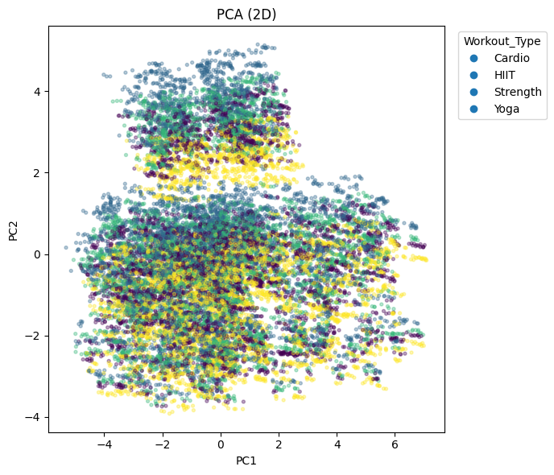

```python
#PCA scatter plot (Workout_Type)
plt.figure(figsize=(7,6))
if label_col is None:
    plt.scatter(Z_pca[:,0], Z_pca[:,1], s=8, alpha=0.35)
else:
    y = df[label_col].astype(str).fillna("NA")
    cats = pd.Categorical(y)
    plt.scatter(Z_pca[:,0], Z_pca[:,1], s=8, alpha=0.35, c=cats.codes)
    handles = []
    for i, cat in enumerate(cats.categories[:12]):
        handles.append(plt.Line2D([0],[0], marker='o', linestyle='', markersize=6, label=cat))
    plt.legend(handles=handles, title=label_col, bbox_to_anchor=(1.02, 1), loc="upper left")

plt.title("PCA (2D)")
plt.xlabel("PC1")
plt.ylabel("PC2")
plt.tight_layout()
plt.show()
```

The PCA projection shows considerable overlap between workout types, suggesting that categorical exercise labels are not the primary drivers of variance. Instead, the dominant directions in the projection likely reflect continuous factors related to physiology and energy balance rather than exercise category alone.

```python
#PCA loadings
loadings = pd.Series(pca.components_[0], index=X_enc.columns).sort_values(key=np.abs, ascending=False)
loadings.head(15)
```

|  | 0 |
| --- | --- |
| Calories | 0.399065 |
| BMI | 0.393831 |
| BMI_calc | 0.393830 |
| lean_mass_kg | 0.384753 |
| Fat_Percentage | 0.369561 |
| cal_balance | 0.333401 |
| protein_per_kg | -0.324239 |
| Water_Intake (liters) | 0.145118 |
| Calories_Burned | -0.048014 |
| Max_BPM | 0.042483 |
| Session_Duration (hours) | -0.038878 |
| Workout_Frequency (days/week) | -0.024833 |
| pct_maxHR | -0.024617 |
| Experience_Level | -0.023315 |
| Resting_BPM | -0.021360 |

**dtype:** float64

The first principal component is dominated by features related to body composition and energy intake, indicating that physiological and metabolic differences form the primary axis of variation in the dataset.

```python
loadings2 = pd.Series(pca.components_[1], index=X_enc.columns).sort_values(key=np.abs, ascending=False)
loadings2.head(15)
```

|  | 0 |
| --- | --- |
| Experience_Level | 0.478808 |
| Session_Duration (hours) | 0.474388 |
| Calories_Burned | 0.466944 |
| Workout_Frequency (days/week) | 0.434795 |
| cal_balance | -0.262175 |
| Water_Intake (liters) | 0.223929 |
| Calories | 0.083963 |
| protein_per_kg | -0.067435 |
| lean_mass_kg | 0.065607 |
| BMI_calc | 0.039993 |
| BMI | 0.039993 |
| Fat_Percentage | 0.015489 |
| Age | -0.011250 |
| pct_HRR | 0.009269 |
| pct_maxHR | 0.006437 |

**dtype:** float64

The second principal component is mainly influenced by activity-related attributes such as workout frequency, session duration, and experience level, capturing differences in training behavior and exercise intensity.

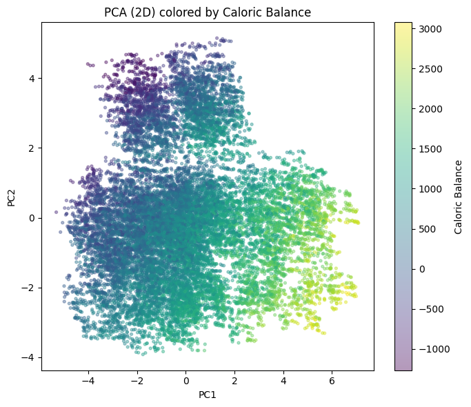

```python
#PCA - Caloric Balance
plt.figure(figsize=(7,6))

sc = plt.scatter(
    Z_pca[:,0],
    Z_pca[:,1],
    s=8,
    alpha=0.4,
    c=df["cal_balance"]
)

plt.colorbar(sc, label="Caloric Balance")
plt.title("PCA (2D) colored by Caloric Balance")
plt.xlabel("PC1")
plt.ylabel("PC2")
plt.tight_layout()
plt.show()
```

Coloring the PCA projection by caloric balance reveals a clear and smooth gradient along the first principal component. Individuals with higher caloric surplus are primarily located toward one end of the projection, while those in caloric deficit cluster toward the opposite side.

This pattern is consistent with the PCA loadings, which indicate that energy intake, body composition, and caloric balance are the dominant contributors to PC1. In contrast, PC2 shows less pronounced variation with respect to caloric balance, suggesting that it captures additional factors beyond energy-related differences.

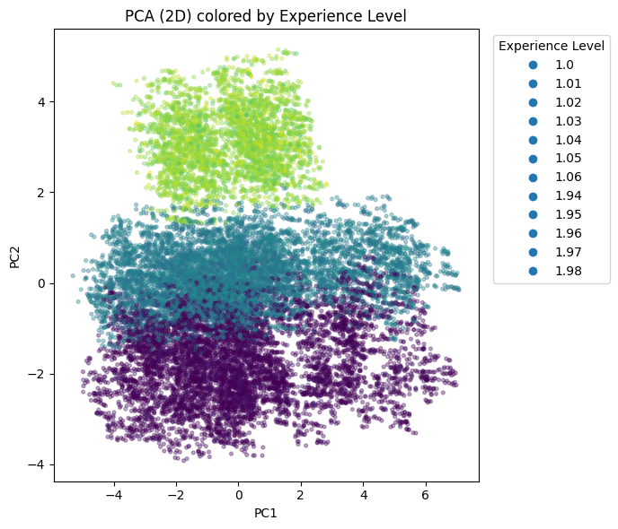

```python
# PCA colored by Experience Level
plt.figure(figsize=(7,6))

y = df["Experience_Level"].astype(str).fillna("NA")
cats = pd.Categorical(y)

plt.scatter(
    Z_pca[:, 0],
    Z_pca[:, 1],
    s=8,
    alpha=0.35,
    c=cats.codes
)

handles = []
for i, cat in enumerate(cats.categories[:12]):
    handles.append(
        plt.Line2D(
            [0], [0],
            marker='o',
            linestyle='',
            markersize=6,
            label=cat
        )
    )

plt.legend(
    handles=handles,
    title="Experience Level",
    bbox_to_anchor=(1.02, 1),
    loc="upper left"
)

plt.title("PCA (2D) colored by Experience Level")
plt.xlabel("PC1")
plt.ylabel("PC2")
plt.tight_layout()
plt.show()
```

Coloring the PCA projection by experience level reveals a clear stratification primarily along the second principal component. Individuals with higher experience levels tend to occupy higher values of PC2, while lower experience levels are concentrated toward the lower part of the projection.

This observation is consistent with the PCA loadings, which show that PC2 is strongly influenced by activity-related attributes such as workout frequency, session duration, and overall training experience. In contrast, experience level shows little variation along PC1, indicating that it is largely independent of the dominant energy and body-composition gradient captured by the first component.

Overall, the PCA analysis reveals that the dominant linear structure in the data is driven by energy balance and body composition, while a secondary axis captures differences in training behavior and experience. Although these global gradients provide meaningful insight into the main sources of variance, the PCA projection shows substantial overlap between individuals and does not reveal clearly separated groups.

To further explore potential non-linear structures and local groupings that are not captured by variance-based methods, we next apply UMAP for projection space exploration.

```python
#UMAP
try:
    import umap
except Exception as e:
    raise ImportError("umap-learn not installed. Install it with: pip install umap-learn") from e
```

```python
#UMAP fit
reducer = umap.UMAP(
    n_components=2,
    n_neighbors=25,
    min_dist=0.10,
    metric="euclidean",
    random_state=0
)
Z_umap = reducer.fit_transform(X_scaled)
Z_umap.shape
```

```
(20000, 2)
```

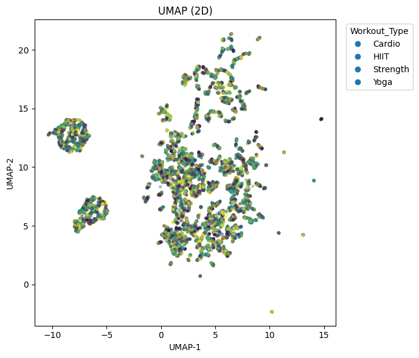

```python
#UMAP scatter plot colored by (Workout_Type)
plt.figure(figsize=(7,6))
if label_col is None:
    plt.scatter(Z_umap[:,0], Z_umap[:,1], s=8, alpha=0.35)
else:
    y = df[label_col].astype(str).fillna("NA")
    cats = pd.Categorical(y)
    plt.scatter(Z_umap[:,0], Z_umap[:,1], s=8, alpha=0.35, c=cats.codes)
    handles = []
    for i, cat in enumerate(cats.categories[:12]):
        handles.append(plt.Line2D([0],[0], marker='o', linestyle='', markersize=6, label=cat))
    plt.legend(handles=handles, title=label_col, bbox_to_anchor=(1.02, 1), loc="upper left")

plt.title("UMAP (2D)")
plt.xlabel("UMAP-1")
plt.ylabel("UMAP-2")
plt.tight_layout()
plt.show()
```

The UMAP projection reveals several well defined clusters in the low dimensional space; however, these clusters are not dominated by a single workout type. Instead, different workout categories are strongly intermixed within the same regions.

This indicates that the local structure captured by UMAP is not primarily driven by categorical exercise type. Individuals engaging in different workouts can exhibit very similar physiological, activity, and nutritional profiles, leading to shared neighborhoods in the projected space.

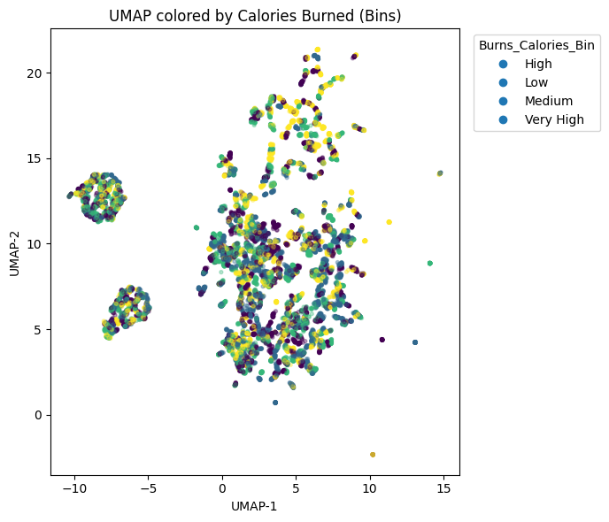

```python
#colored by (Calories_Burned)
color_col = "Burns_Calories_Bin"

plt.figure(figsize=(7,6))
y = df[color_col].astype(str).fillna("NA")
cats = pd.Categorical(y)

plt.scatter(
    Z_umap[:,0],
    Z_umap[:,1],
    s=8,
    alpha=0.35,
    c=cats.codes
)

handles = [
    plt.Line2D([0],[0], marker='o', linestyle='', markersize=6, label=cat)
    for cat in cats.categories
]

plt.legend(handles=handles, title=color_col, bbox_to_anchor=(1.02,1), loc="upper left")
plt.title("UMAP colored by Calories Burned (Bins)")
plt.xlabel("UMAP-1")
plt.ylabel("UMAP-2")
plt.tight_layout()
plt.show()
```

Coloring the UMAP projection by calories burned reveals a noticeable structuring within the projected space. While different calorie-burn levels still overlap, higher burn categories tend to concentrate in specific regions rather than being uniformly distributed.

This suggests that exercise intensity contributes to the local neighborhood structure captured by UMAP, although it is not sufficient on its own to produce fully separated clusters. The observed overlap indicates that individuals with similar calorie expenditure may still differ along other physiological or nutritional dimensions.

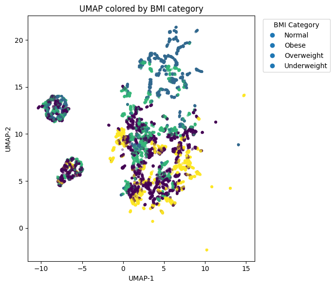

```python
#colored by (BMI_Catigory)
df["BMI_bin"] = pd.cut(
    df["BMI"],
    bins=[0, 18.5, 25, 30, 100],
    labels=["Underweight", "Normal", "Overweight", "Obese"]
)
plt.figure(figsize=(7,6))
y = df["BMI_bin"].astype(str).fillna("NA")
cats = pd.Categorical(y)

plt.scatter(
    Z_umap[:,0],
    Z_umap[:,1],
    s=8,
    alpha=0.35,
    c=cats.codes
)

handles = [
    plt.Line2D([0],[0], marker='o', linestyle='', markersize=6, label=cat)
    for cat in cats.categories
]

plt.legend(handles=handles, title="BMI Category", bbox_to_anchor=(1.02,1), loc="upper left")
plt.title("UMAP colored by BMI category")
plt.xlabel("UMAP-1")
plt.ylabel("UMAP-2")
plt.tight_layout()
plt.show()
```

Coloring the UMAP projection by BMI category reveals a clearer structural pattern than exercise type or calorie-burn bins. Several regions of the projected space are dominated by specific BMI categories, particularly for underweight and obese individuals, which tend to concentrate in more localized neighborhoods.

While overlap between categories remains, the observed spatial separation suggests that body composition plays a stronger role in shaping the non-linear structure of the data. This indicates that BMI-related physiological differences are a more influential factor for local similarity than categorical workout labels.

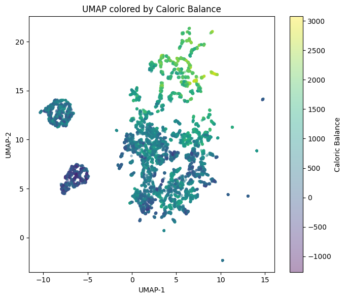

```python
#colored by (Calorie_Balance)
plt.figure(figsize=(7,6))

sc = plt.scatter(
    Z_umap[:,0],
    Z_umap[:,1],
    s=8,
    alpha=0.4,
    c=df["cal_balance"],
)

plt.colorbar(sc, label="Caloric Balance")
plt.title("UMAP colored by Caloric Balance")
plt.xlabel("UMAP-1")
plt.ylabel("UMAP-2")
plt.tight_layout()
plt.show()
```

Coloring the UMAP projection by caloric balance reveals a strong and coherent structure across the embedding. Regions of the space exhibit clear gradients from caloric deficit to caloric surplus, with locally consistent neighborhoods sharing similar energy balance values.

Compared to previous colorings, caloric balance aligns more closely with the non-linear structure uncovered by UMAP, suggesting that the combination of energy intake and expenditure is a key factor driving similarity between individuals. This highlights caloric balance as a more informative explanatory variable than exercise type or calorie-burn categories alone.

The pronounced structure observed in the UMAP embedding suggests the presence of coherent local groupings. To further characterize these patterns, we apply a density-based clustering method in the projected space.

```python
from sklearn.cluster import DBSCAN

dbscan = DBSCAN(
    eps=0.6,
    min_samples=20
)

cluster_id = dbscan.fit_predict(Z_umap)

# نضيف الcluster IDs للداتا
df_analysis = df.copy()
df_analysis["cluster_id"] = cluster_id

df_analysis["cluster_id"].value_counts()
```

| cluster_id | count |
| --- | --- |
| 0 | 11812 |
| 1 | 2427 |
| 3 | 2128 |
| 2 | 1789 |
| 6 | 360 |
| 5 | 299 |
| 8 | 253 |
| 4 | 201 |
| 13 | 143 |
| 10 | 103 |
| 11 | 86 |
| 7 | 53 |
| 16 | 48 |
| 17 | 46 |
| 19 | 44 |
| 9 | 34 |
| 18 | 28 |
| 20 | 28 |
| 14 | 26 |
| 22 | 26 |
| 15 | 24 |
| 21 | 22 |
| 12 | 20 |

**dtype:** int64

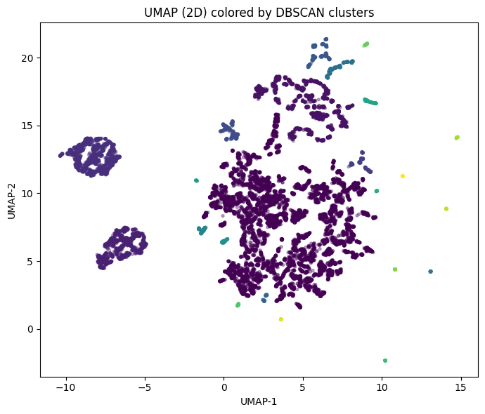

```python
plt.figure(figsize=(7,6))
plt.scatter(
    Z_umap[:,0],
    Z_umap[:,1],
    c=cluster_id,
    s=8,
    alpha=0.35
)

plt.title("UMAP (2D) colored by DBSCAN clusters")
plt.xlabel("UMAP-1")
plt.ylabel("UMAP-2")
plt.tight_layout()
plt.show()
```

Coloring the UMAP projection by DBSCAN cluster assignments reveals that the algorithm closely follows the local structure uncovered by UMAP. Dense regions in the embedding correspond to large clusters, while peripheral or elongated regions are assigned to smaller clusters or isolated groups.

The resulting clusters align well with previously observed gradients in caloric balance and body composition, indicating that the detected groupings reflect meaningful similarities in physiological and energy-related profiles rather than noise or arbitrary partitioning.

```python
explain_features = [
    "Age", "BMI", "Fat_Percentage", "lean_mass_kg",
    "Resting_BPM", "Avg_BPM",
    "Workout_Frequency (days/week)", "Session_Duration (hours)",
    "Calories_Burned",
    "cal_balance", "protein_per_kg", "Water_Intake (liters)"
]

explain_features = [c for c in explain_features if c in df_analysis.columns]
```

To interpret the detected clusters, a subset of physiologically and behaviorally meaningful features is selected, focusing on body composition, cardiovascular response, activity patterns, and energy balance.

```python
cluster_summary = (
    df_analysis
    .groupby("cluster_id")[explain_features]
    .median()
    .round(2)
)

cluster_summary
```

| cluster_id | Age | BMI | Fat_Percentage | lean_mass_kg | Resting_BPM | Avg_BPM | Workout_Frequency (days/week) | Session_Duration (hours) | Calories_Burned | cal_balance | protein_per_kg | Water_Intake (liters) |
| --- | --- | --- | --- | --- | --- | --- | --- | --- | --- | --- | --- | --- |
| 0 | 40.34 | 22.40 | 24.48 | 48.30 | 62.18 | 141.83 | 3.00 | 1.18 | 1111.00 | 648.42 | 1.53 | 2.30 |
| 1 | 34.78 | 32.75 | 32.82 | 72.92 | 63.78 | 141.60 | 3.00 | 1.16 | 1074.94 | 1780.00 | 0.91 | 2.90 |
| 2 | 39.79 | 23.14 | 24.13 | 45.77 | 61.10 | 140.70 | 4.97 | 1.79 | 1952.40 | -219.06 | 1.61 | 2.70 |
| 3 | 38.52 | 25.65 | 26.72 | 62.14 | 65.02 | 144.32 | 4.97 | 1.76 | 1941.26 | 439.25 | 1.14 | 3.50 |
| 4 | 39.15 | 23.93 | 25.86 | 58.24 | 67.92 | 141.20 | 2.01 | 0.74 | 712.80 | 1441.63 | 1.18 | 3.51 |
| 5 | 47.31 | 27.94 | 28.75 | 62.54 | 66.22 | 155.97 | 3.01 | 1.29 | 1248.00 | 1124.98 | 1.22 | 3.39 |
| 6 | 35.68 | 44.73 | 35.00 | 80.08 | 59.96 | 153.04 | 3.04 | 1.28 | 1305.11 | 1884.26 | 0.84 | 2.79 |
| 7 | 53.61 | 20.47 | 21.13 | 35.77 | 58.03 | 165.03 | 2.03 | 1.37 | 1169.26 | 142.88 | 2.49 | 1.97 |
| 8 | 49.17 | 39.36 | 35.00 | 70.77 | 61.00 | 164.97 | 2.99 | 1.20 | 968.00 | 1751.57 | 0.96 | 3.11 |
| 9 | 51.02 | 15.48 | 19.12 | 39.37 | 74.00 | 155.02 | 2.00 | 1.47 | 1373.31 | -10.73 | 3.19 | 3.50 |
| 10 | 53.09 | 17.73 | 20.22 | 43.73 | 65.97 | 136.77 | 3.98 | 1.35 | 1384.70 | 151.02 | 2.21 | 3.49 |
| 11 | 21.78 | 19.36 | 22.31 | 50.58 | 55.59 | 149.22 | 3.99 | 1.23 | 1252.28 | 591.10 | 1.26 | 3.36 |
| 12 | 38.94 | 22.96 | 25.17 | 46.45 | 54.11 | 127.09 | 2.99 | 0.97 | 858.00 | 916.92 | 2.68 | 3.20 |
| 13 | 46.68 | 41.13 | 35.00 | 79.56 | 59.90 | 156.85 | 2.00 | 0.73 | 677.60 | 2518.02 | 0.76 | 3.11 |
| 14 | 53.04 | 23.00 | 25.37 | 45.65 | 73.97 | 124.10 | 3.00 | 0.54 | 479.15 | 1159.64 | 1.51 | 3.40 |
| 15 | 23.93 | 15.02 | 18.62 | 32.91 | 55.01 | 167.97 | 2.00 | 0.99 | 875.60 | 258.44 | 3.44 | 1.90 |
| 16 | 45.56 | 14.48 | 18.54 | 37.75 | 57.84 | 161.73 | 3.01 | 1.47 | 1556.50 | -132.61 | 2.09 | 3.58 |
| 17 | 58.69 | 44.64 | 35.00 | 82.26 | 68.27 | 148.63 | 2.98 | 1.23 | 959.43 | 2343.61 | 0.76 | 2.88 |
| 18 | 27.00 | 18.10 | 21.51 | 45.53 | 72.96 | 143.01 | 2.00 | 1.39 | 1375.48 | 195.64 | 1.44 | 1.50 |
| 19 | 57.82 | 16.44 | 19.57 | 36.45 | 69.84 | 129.02 | 4.00 | 1.28 | 1237.88 | 139.43 | 3.62 | 1.79 |
| 20 | 18.00 | 30.53 | 30.91 | 63.69 | 50.08 | 167.85 | 2.00 | 1.41 | 1395.26 | 1073.01 | 1.22 | 3.09 |
| 21 | 23.94 | 18.05 | 21.31 | 43.02 | 53.02 | 166.90 | 3.01 | 0.84 | 747.32 | 803.10 | 2.41 | 3.60 |
| 22 | 34.10 | 24.08 | 25.74 | 50.40 | 56.94 | 128.00 | 2.00 | 0.67 | 658.64 | 1268.10 | 2.52 | 3.40 |

The table summarizes each DBSCAN cluster using median values of key explanatory features. Distinct cluster profiles emerge, with noticeable differences in body composition, activity intensity, and caloric balance across groups. These summaries confirm that the clusters detected in the UMAP space correspond to meaningful lifestyle patterns rather than arbitrary geometric partitions.

```python
non_noise = cluster_summary.drop(index=-1, errors="ignore")

feature_spread = (non_noise.max() - non_noise.min()).sort_values(ascending=False)
feature_spread.head(10)
```

|  | 0 |
| --- | --- |
| cal_balance | 2737.08 |
| Calories_Burned | 1473.25 |
| lean_mass_kg | 49.35 |
| Avg_BPM | 43.87 |
| Age | 40.69 |
| BMI | 30.25 |
| Resting_BPM | 23.92 |
| Fat_Percentage | 16.46 |
| Workout_Frequency (days/week) | 2.97 |
| protein_per_kg | 2.86 |

**dtype:** float64

Comparing the range of feature values across clusters shows that caloric balance exhibits the largest variation, followed by calories burned and lean body mass. This indicates that differences in energy balance and activity intensity are the primary factors distinguishing the identified clusters.

In contrast, variables such as workout frequency and protein intake show more limited variation, suggesting a secondary role in defining cluster structure.

```python
#TSNE

from sklearn.manifold import TSNE

tsne = TSNE(n_components=2, perplexity=30, learning_rate="auto", init="pca", random_state=0)
Z_tsne = tsne.fit_transform(X_scaled)
Z_tsne.shape
```

```
(20000, 2)
```

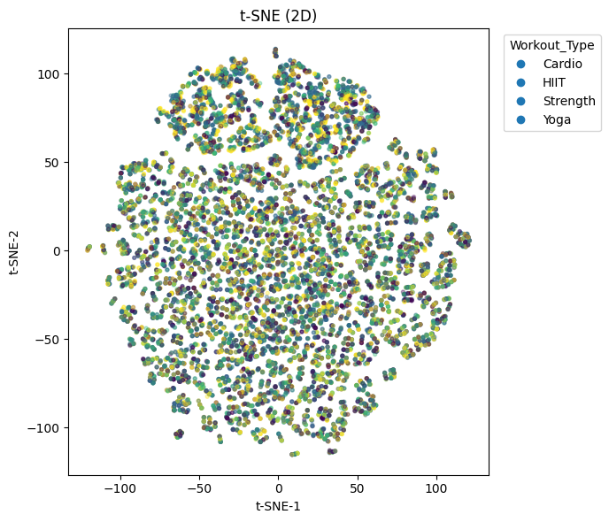

```python
#TSNE (Workout_Type)
plt.figure(figsize=(7,6))
if label_col is None:
    plt.scatter(Z_tsne[:,0], Z_tsne[:,1], s=8, alpha=0.35)
else:
    y = df[label_col].astype(str).fillna("NA")
    cats = pd.Categorical(y)
    plt.scatter(Z_tsne[:,0], Z_tsne[:,1], s=8, alpha=0.35, c=cats.codes)
    handles = []
    for i, cat in enumerate(cats.categories[:12]):
        handles.append(plt.Line2D([0],[0], marker='o', linestyle='', markersize=6, label=cat))
    plt.legend(handles=handles, title=label_col, bbox_to_anchor=(1.02, 1), loc="upper left")

plt.title("t-SNE (2D)")
plt.xlabel("t-SNE-1")
plt.ylabel("t-SNE-2")
plt.tight_layout()
plt.show()
```

The t-SNE projection shows a largely continuous and compact structure with no clear separation between different workout types. Similar to the PCA results, exercise categories are strongly intermixed across the embedding, indicating that workout type alone does not define local similarity between individuals.

Compared to UMAP, the t-SNE embedding exhibits less globally coherent structure and emphasizes local neighborhoods without forming stable, well-separated regions. This supports the interpretation that categorical workout labels are not the primary drivers of similarity in the high-dimensional lifestyle data.

```python
#Cluster the UMAP space
from sklearn.cluster import DBSCAN

db = DBSCAN(eps=0.6, min_samples=20)
cluster_id = db.fit_predict(Z_umap)

df_analysis = df.copy()
df_analysis["cluster_id"] = cluster_id

df_analysis["cluster_id"].value_counts().head(10)
```

| cluster_id | count |
| --- | --- |
| 0 | 11812 |
| 1 | 2427 |
| 3 | 2128 |
| 2 | 1789 |
| 6 | 360 |
| 5 | 299 |
| 8 | 253 |
| 4 | 201 |
| 13 | 143 |
| 10 | 103 |

**dtype:** int64

DBSCAN identifies a small number of large clusters alongside several smaller ones. The largest cluster contains a substantial portion of the dataset, indicating a dominant lifestyle profile shared by many individuals. In contrast, the presence of multiple smaller clusters suggests more specialized or less common patterns in the data.

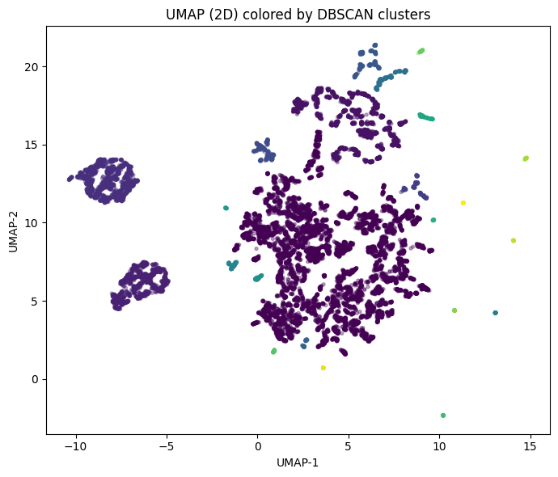

```python
#UMAP with cluster labels colored by (DBSCAN_Cluster)
plt.figure(figsize=(7,6))
plt.scatter(Z_umap[:,0], Z_umap[:,1], s=8, alpha=0.35, c=cluster_id)
plt.title("UMAP (2D) colored by DBSCAN clusters")
plt.xlabel("UMAP-1")
plt.ylabel("UMAP-2")
plt.tight_layout()
plt.show()
```

Coloring the UMAP embedding by DBSCAN cluster assignments shows that the clustering closely follows the local density structure of the projected space. Dense regions are grouped into large clusters, while more isolated or elongated regions form smaller clusters.

This alignment indicates that DBSCAN effectively captures the intrinsic structure revealed by UMAP rather than imposing arbitrary partitions on the data.

```python
#Explain clusters using the original features
explain_cols = [c for c in preferred_features if c in df_analysis.columns and pd.api.types.is_numeric_dtype(df_analysis[c])]
summary = df_analysis.groupby("cluster_id")[explain_cols].median().sort_index()
summary.head()
```

| cluster_id | Age | BMI | BMI_calc | Fat_Percentage | lean_mass_kg | Resting_BPM | Avg_BPM | pct_maxHR | pct_HRR | Max_BPM | Workout_Frequency (days/week) | Session_Duration (hours) | Calories_Burned | Experience_Level | cal_balance | protein_per_kg | Water_Intake (liters) | Calories | pct_carbs |
| --- | --- | --- | --- | --- | --- | --- | --- | --- | --- | --- | --- | --- | --- | --- | --- | --- | --- | --- | --- |
| 0 | 40.340 | 22.40 | 22.399212 | 24.483145 | 48.302817 | 62.18 | 141.83 | 0.783594 | 0.669338 | 179.840 | 3.00 | 1.18 | 1111.00 | 1.98 | 648.42 | 1.528858 | 2.30 | 1774.0 | 0.499987 |
| 1 | 34.780 | 32.75 | 32.754390 | 32.818822 | 72.915989 | 63.78 | 141.60 | 0.777343 | 0.670072 | 185.320 | 3.00 | 1.16 | 1074.94 | 1.02 | 1780.00 | 0.907045 | 2.90 | 2840.0 | 0.499950 |
| 2 | 39.790 | 23.14 | 23.140898 | 24.129496 | 45.771584 | 61.10 | 140.70 | 0.773951 | 0.657693 | 181.140 | 4.97 | 1.79 | 1952.40 | 3.00 | -219.06 | 1.605413 | 2.70 | 1748.0 | 0.499938 |
| 3 | 38.515 | 25.65 | 25.647089 | 26.720107 | 62.144570 | 65.02 | 144.32 | 0.811446 | 0.707543 | 181.535 | 4.97 | 1.76 | 1941.26 | 3.00 | 439.25 | 1.135533 | 3.50 | 2373.0 | 0.500064 |
| 4 | 39.150 | 23.93 | 23.927102 | 25.858496 | 58.240836 | 67.92 | 141.20 | 0.835207 | 0.725042 | 170.700 | 2.01 | 0.74 | 712.80 | 1.00 | 1441.63 | 1.177300 | 3.51 | 2125.0 | 0.499764 |

```python
if -1 in summary.index and len(summary.index) > 2:
    non_noise = summary.drop(index=-1)
else:
    non_noise = summary

spread = (non_noise.max(axis=0) - non_noise.min(axis=0)).sort_values(ascending=False)
spread.head(12)
```

|  | 0 |
| --- | --- |
| cal_balance | 2737.080000 |
| Calories | 2167.000000 |
| Calories_Burned | 1473.250000 |
| lean_mass_kg | 49.347338 |
| Avg_BPM | 43.875000 |
| Age | 40.695000 |
| Max_BPM | 38.975000 |
| BMI | 30.245000 |
| BMI_calc | 30.244153 |
| Resting_BPM | 23.920000 |
| Fat_Percentage | 16.458575 |
| Workout_Frequency (days/week) | 2.975000 |

**dtype:** float64

The cluster-wise medians reveal distinct lifestyle profiles across the identified groups. Noticeable differences emerge in body composition, cardiovascular response, and activity intensity, with some clusters characterized by higher BMI and caloric surplus, while others show leaner profiles and higher activity levels.

These numerical summaries provide concrete evidence that the clusters correspond to interpretable physiological and behavioral patterns.

This confirms that the detected clusters are primarily driven by differences in energy balance and activity intensity, consistent with patterns observed in both PCA and UMAP projections.

Overall, density-based clustering on the UMAP embedding reveals coherent and interpretable lifestyle groups. The identified clusters reflect meaningful differences in energy balance, body composition, and activity behavior rather than categorical exercise labels alone.

## Final Conclusion

This project explored a high-dimensional fitness and nutrition dataset using projection-based methods to uncover underlying structure and behavioral patterns. PCA provided a global, linear view of the data, revealing that variations in body composition, caloric intake, and energy balance dominate the primary axes of variance. While exercise type showed substantial overlap, continuous physiological and nutritional features emerged as the main drivers of separation.

UMAP offered a complementary, non-linear perspective, uncovering well-defined local structures and dense regions that were not apparent in the PCA space. Coloring the UMAP embedding by caloric expenditure, BMI category, and caloric balance revealed smooth gradients and localized concentrations, indicating meaningful organization beyond categorical workout labels.

Overall, the combination of PCA, UMAP, and density-based clustering demonstrates that projection-based analysis can effectively reveal meaningful and interpretable structure in complex health and fitness data, providing insights that go beyond surface-level categorical attributes.